# DEFENSIVE TRAITS A.barbata SIBECOL 2025

Andrés Delgado Galán

2025-05-09

### A.barbata - PRODUCCIÓN DE FLORES

**flor ~ trat + clip + trat:clip**  
n = **53**

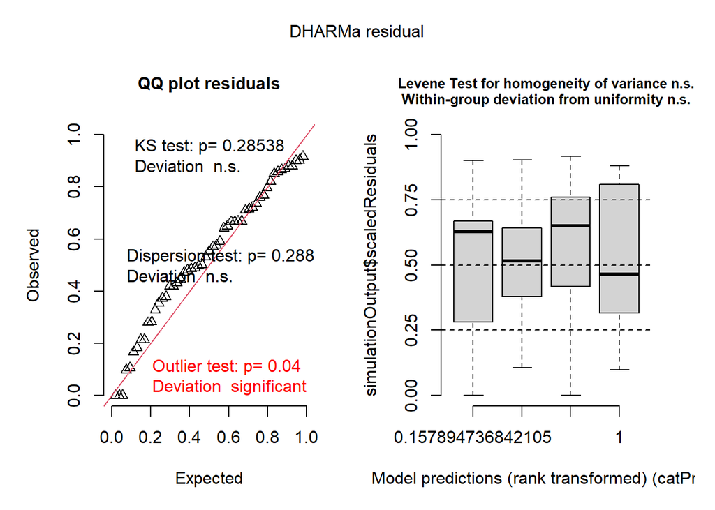

##### AVflor Post-hoc Comparisons with Tukeys HSD

| contrast | trat | estimate | SE | df | z.ratio | p.value |
| --- | --- | --- | --- | --- | --- | --- |
| no - yes | ex | -0.0178062 | 0.2119446 | Inf | -0.0840136 | 0.9330456 |
| no - yes | gra | 0.3346080 | 0.2070219 | Inf | 1.6162928 | 0.1060310 |

| contrast | clip | estimate | SE | df | z.ratio | p.value |
| --- | --- | --- | --- | --- | --- | --- |
| ex - gra | no | -1.0175712 | 0.2105174 | Inf | -4.833667 | 0.0000013 |
| ex - gra | yes | -0.6651569 | 0.2084730 | Inf | -3.190613 | 0.0014197 |

ANOVA Results for AVflor Model

| Response | Predictor | Chisq | Df | Pr(>Chisq) |
| --- | --- | --- | --- | --- |
| AV flor | trat *** | 32.129 | 1 | 0.000 |
| AV flor | clip | 1.205 | 1 | 0.272 |
| AV flor | trat:clip | 1.415 | 1 | 0.234 |

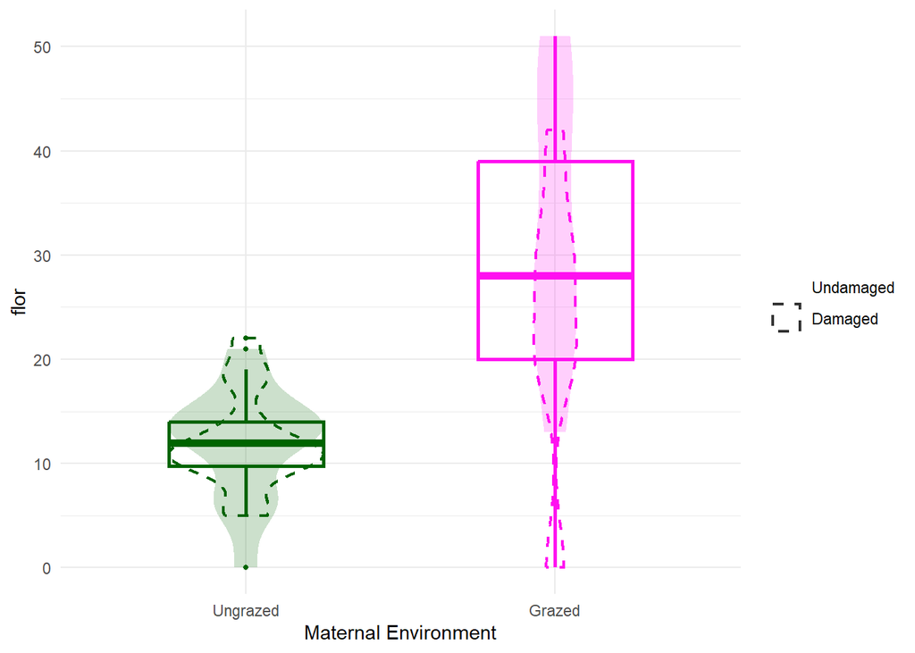

### A.barbata - PRODUCCIÓN DE FRUTOS

**fruto ~ trat + clip + trat:clip**  
n = **53**

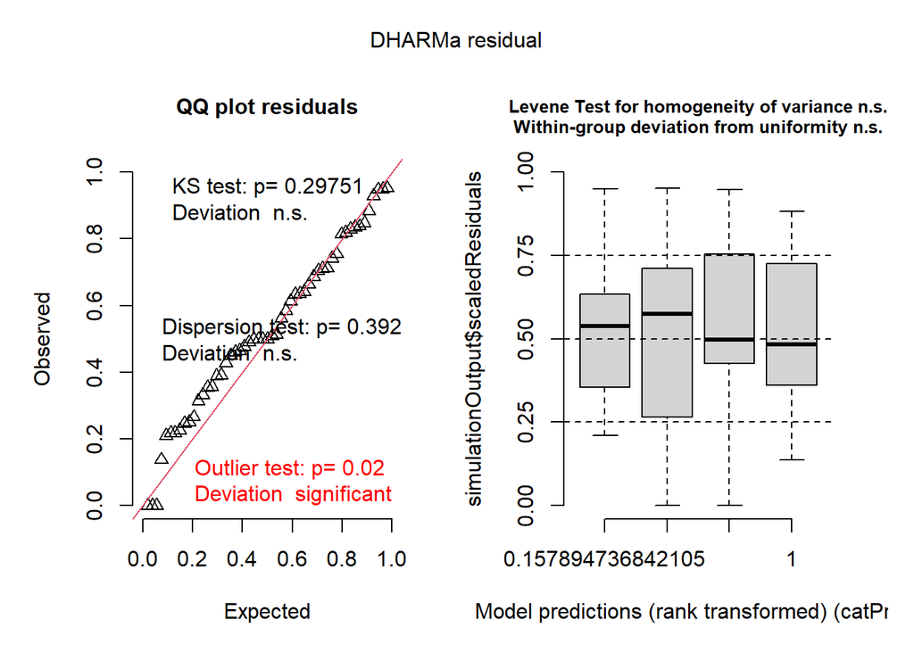

##### AVfruto Post-hoc Comparisons with Tukeys HSD

| contrast | trat | estimate | SE | df | z.ratio | p.value |
| --- | --- | --- | --- | --- | --- | --- |
| no - yes | ex | 0.1144103 | 0.2111954 | Inf | 0.5417271 | 0.5880065 |
| no - yes | gra | 0.2027781 | 0.2010815 | Inf | 1.0084375 | 0.3132445 |

| contrast | clip | estimate | SE | df | z.ratio | p.value |
| --- | --- | --- | --- | --- | --- | --- |
| ex - gra | no | -0.9529965 | 0.2063730 | Inf | -4.617835 | 3.90e-06 |
| ex - gra | yes | -0.8646287 | 0.2060277 | Inf | -4.196662 | 2.71e-05 |

ANOVA Results for AVfruto Model

| Response | Predictor | Chisq | Df | Pr(>Chisq) |
| --- | --- | --- | --- | --- |
| AV fruto | trat *** | 38.845 | 1 | 0.000 |
| AV fruto | clip | 1.219 | 1 | 0.270 |
| AV fruto | trat:clip | 0.092 | 1 | 0.762 |

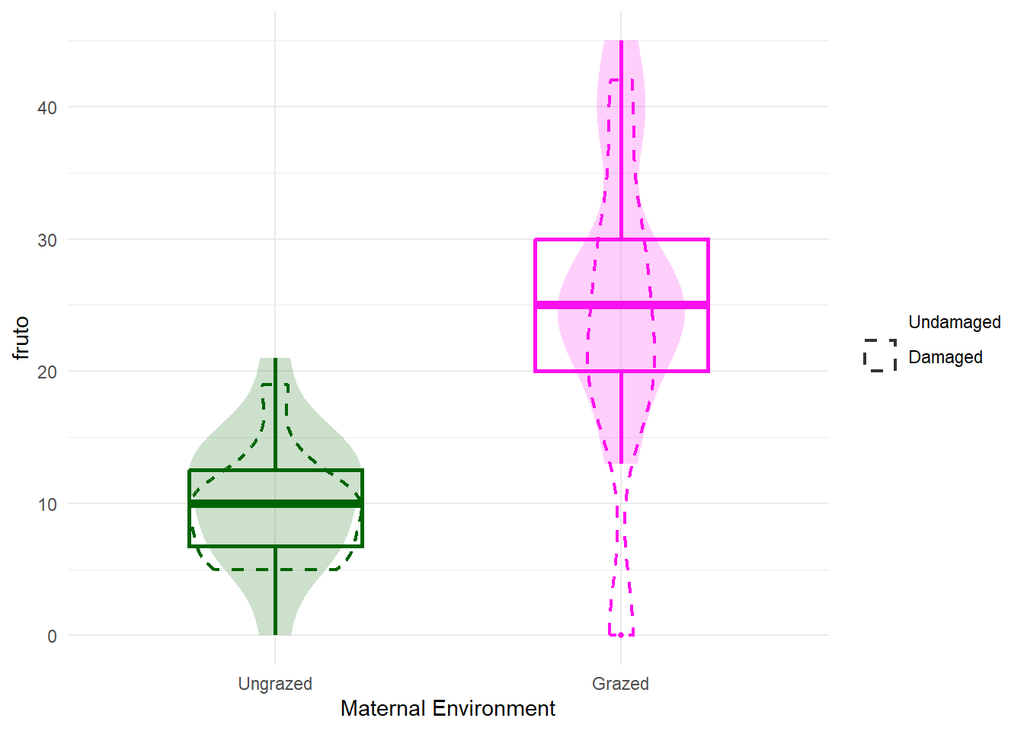

### A.barbata - PRODUCCIÓN DE HOJAS

**hojas ~ trat + clip + trat:clip**  
n = **53**

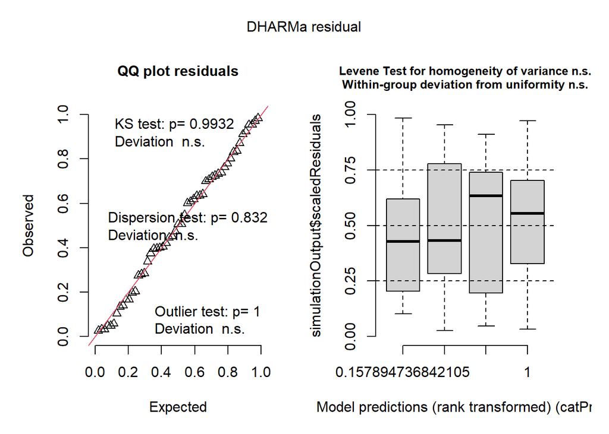

##### AVhojas Post-hoc Comparisons with Tukeys HSD

| contrast | trat | estimate | SE | df | z.ratio | p.value |
| --- | --- | --- | --- | --- | --- | --- |
| no - yes | ex | -0.2077479 | 0.1060864 | Inf | -1.9582901 | 0.0501960 |
| no - yes | gra | 0.0034558 | 0.1060884 | Inf | 0.0325745 | 0.9740139 |

| contrast | clip | estimate | SE | df | z.ratio | p.value |
| --- | --- | --- | --- | --- | --- | --- |
| ex - gra | no | -0.5915090 | 0.1078916 | Inf | -5.482437 | 0.0000000 |
| ex - gra | yes | -0.3803053 | 0.1042519 | Inf | -3.647946 | 0.0002643 |

ANOVA Results for AVhojas Model

| Response | Predictor | Chisq | Df | Pr(>Chisq) |
| --- | --- | --- | --- | --- |
| AV hojas | trat *** | 41.383 | 1 | 0.000 |
| AV hojas | clip | 1.854 | 1 | 0.173 |
| AV hojas | trat:clip | 1.982 | 1 | 0.159 |

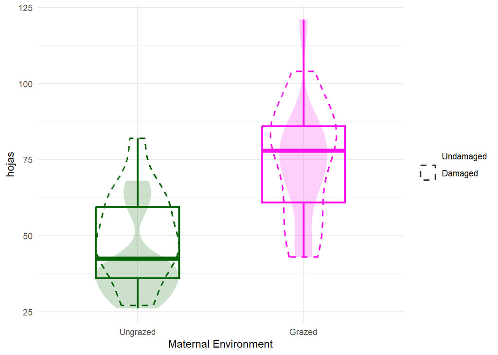

### A.barbata - ALTURA MÁXIMA

**altura ~ trat + clip + trat:clip**  
n = **51**

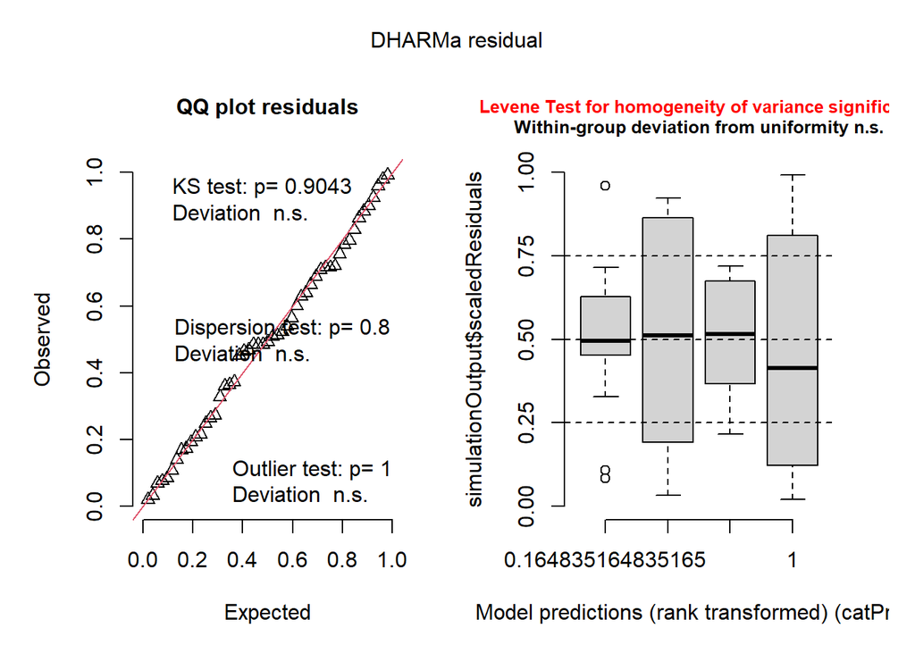

R² = **0.1140911**

##### AValtura Post-hoc Comparisons with Tukeys HSD

| contrast | trat | estimate | SE | df | t.ratio | p.value |
| --- | --- | --- | --- | --- | --- | --- |
| no - yes | ex | 9.618132 | 7.494362 | 47 | 1.2833824 | 0.2056501 |
| no - yes | gra | 7.000000 | 7.943517 | 47 | 0.8812217 | 0.3826822 |

| contrast | clip | estimate | SE | df | t.ratio | p.value |
| --- | --- | --- | --- | --- | --- | --- |
| ex - gra | no | -12.97115 | 7.789260 | 47 | -1.665261 | 0.1025136 |
| ex - gra | yes | -15.58929 | 7.654565 | 47 | -2.036600 | 0.0473457 |

ANOVA Results for AValtura Model

| Response | Predictor | Sum Sq | Df | F value | Pr(>F) |
| --- | --- | --- | --- | --- | --- |
| AV altura | trat * | 2598.447 | 1 | 6.863 | 0.012 |
| AV altura | clip | 895.816 | 1 | 2.366 | 0.131 |
| AV altura | trat:clip | 21.759 | 1 | 0.057 | 0.812 |
| AV altura | Residuals | 17794.049 | 47 | NA | NA |

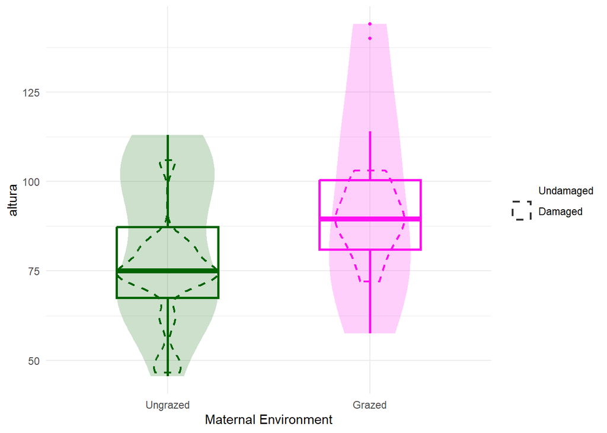

### A.barbata - SEMILLAS/FRUTO

**seedfruto ~ trat + clip + trat:clip**  
n = **53**

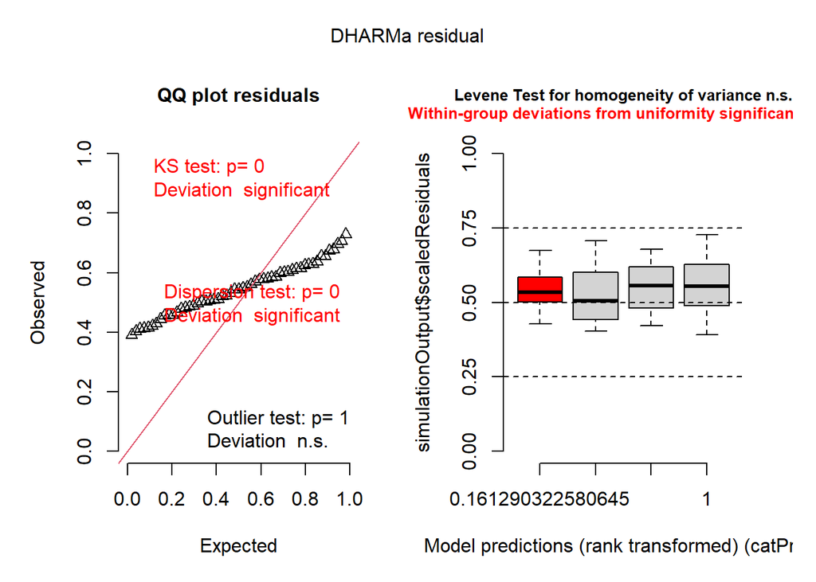

##### AVseedfruto Post-hoc Comparisons with Tukeys HSD

| contrast | trat | estimate | SE | df | z.ratio | p.value |
| --- | --- | --- | --- | --- | --- | --- |
| no - yes | ex | -1.3e-06 | 0.2672612 | Inf | -4.8e-06 | 0.9999962 |
| no - yes | gra | 8.0e-07 | 0.2830692 | Inf | 2.9e-06 | 0.9999977 |

| contrast | clip | estimate | SE | df | z.ratio | p.value |
| --- | --- | --- | --- | --- | --- | --- |
| ex - gra | no | -1.3e-06 | 0.2781742 | Inf | -4.5e-06 | 0.9999964 |
| ex - gra | yes | 8.0e-07 | 0.2723523 | Inf | 3.1e-06 | 0.9999976 |

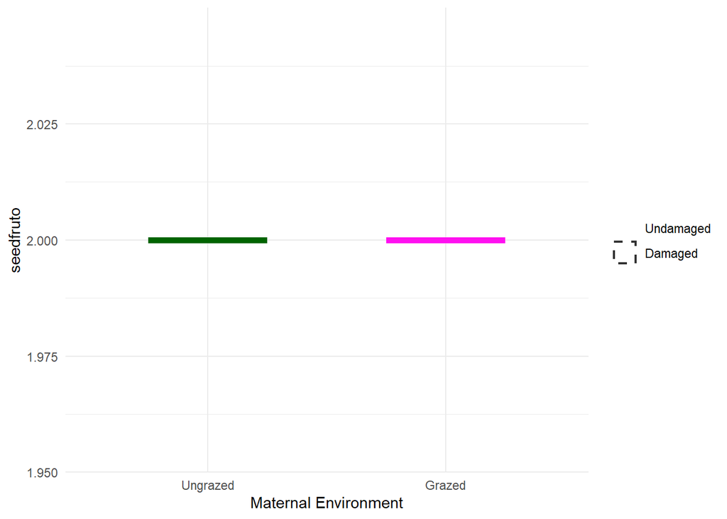

### A.barbata - PRODUCCIÓN DE SEMILLAS

**seedtotal ~ trat + clip + trat:clip**  
n = **53**

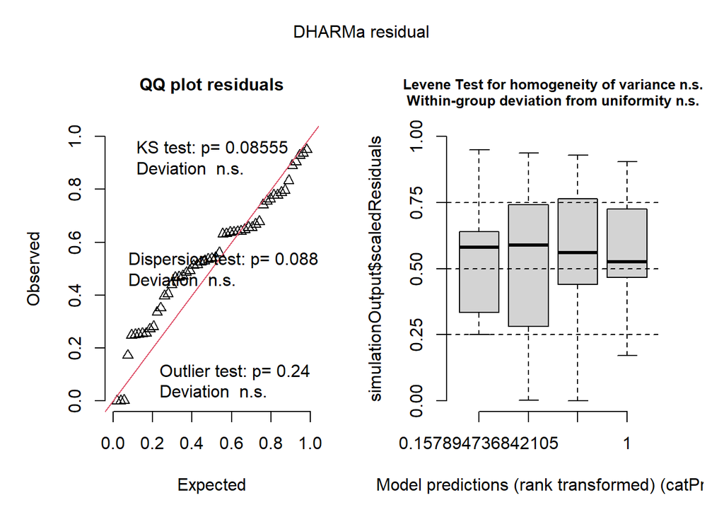

##### AVseedtotal Post-hoc Comparisons with Tukeys HSD

| contrast | trat | estimate | SE | df | z.ratio | p.value |
| --- | --- | --- | --- | --- | --- | --- |
| no - yes | ex | 0.1144103 | 0.2258607 | Inf | 0.5065528 | 0.6124687 |
| no - yes | gra | 0.2027771 | 0.2289652 | Inf | 0.8856241 | 0.3758201 |

| contrast | clip | estimate | SE | df | z.ratio | p.value |
| --- | --- | --- | --- | --- | --- | --- |
| ex - gra | no | -0.9529960 | 0.2289079 | Inf | -4.163229 | 0.0000314 |
| ex - gra | yes | -0.8646293 | 0.2259188 | Inf | -3.827169 | 0.0001296 |

ANOVA Results for AVseedtotal Model

| Response | Predictor | Chisq | Df | Pr(>Chisq) |
| --- | --- | --- | --- | --- |
| AV seedtotal | trat *** | 31.904 | 1 | 0.000 |
| AV seedtotal | clip | 0.965 | 1 | 0.326 |
| AV seedtotal | trat:clip | 0.075 | 1 | 0.784 |

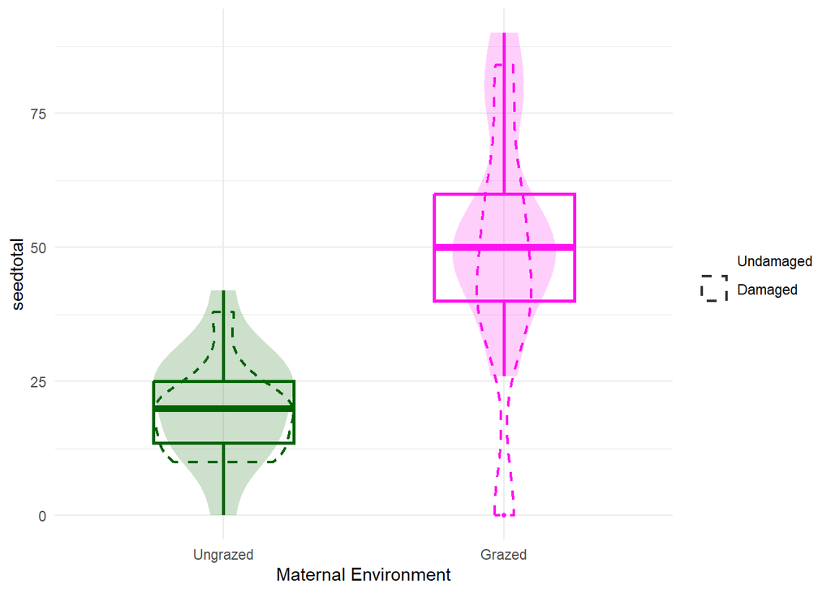

### A.barbata - PESO MEDIO DE LAS SEMILLAS

**massseed ~ trat + clip + trat:clip**  
n = **49**

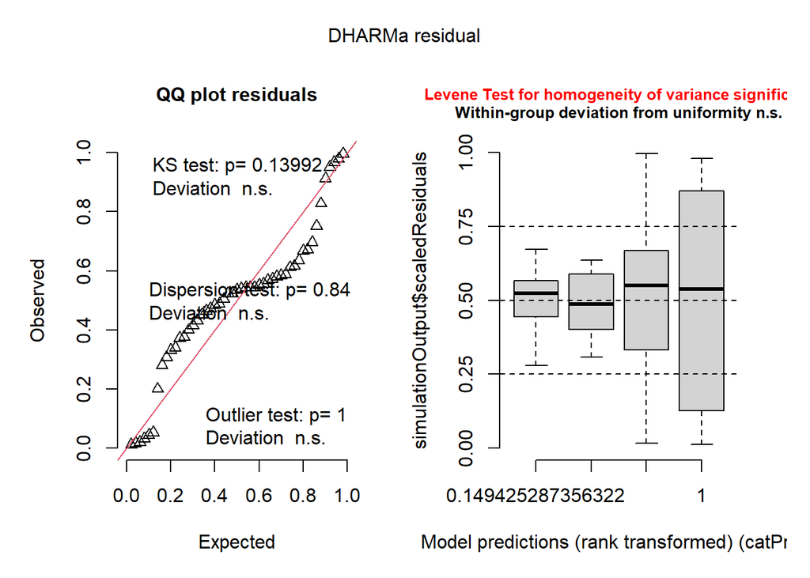

R² = **0.7454588**

##### AVmassseed Post-hoc Comparisons with Tukeys HSD

| contrast | trat | estimate | SE | df | t.ratio | p.value |
| --- | --- | --- | --- | --- | --- | --- |
| no - yes | ex | 0.0017357 | 0.0022118 | 45 | 0.7847651 | 0.4367034 |
| no - yes | gra | 0.0002765 | 0.0023468 | 45 | 0.1178245 | 0.9067311 |

| contrast | clip | estimate | SE | df | t.ratio | p.value |
| --- | --- | --- | --- | --- | --- | --- |
| ex - gra | no | 0.0200318 | 0.0023468 | 45 | 8.535655 | 0 |
| ex - gra | yes | 0.0185726 | 0.0022118 | 45 | 8.397201 | 0 |

ANOVA Results for AVmassseed Model

| Response | Predictor | Sum Sq | Df | F value | Pr(>F) |
| --- | --- | --- | --- | --- | --- |
| AV massseed | trat *** | 0.005 | 1 | 143.166 | 0.000 |
| AV massseed | clip | 0.000 | 1 | 0.425 | 0.518 |
| AV massseed | trat:clip | 0.000 | 1 | 0.205 | 0.653 |
| AV massseed | Residuals | 0.001 | 45 | NA | NA |

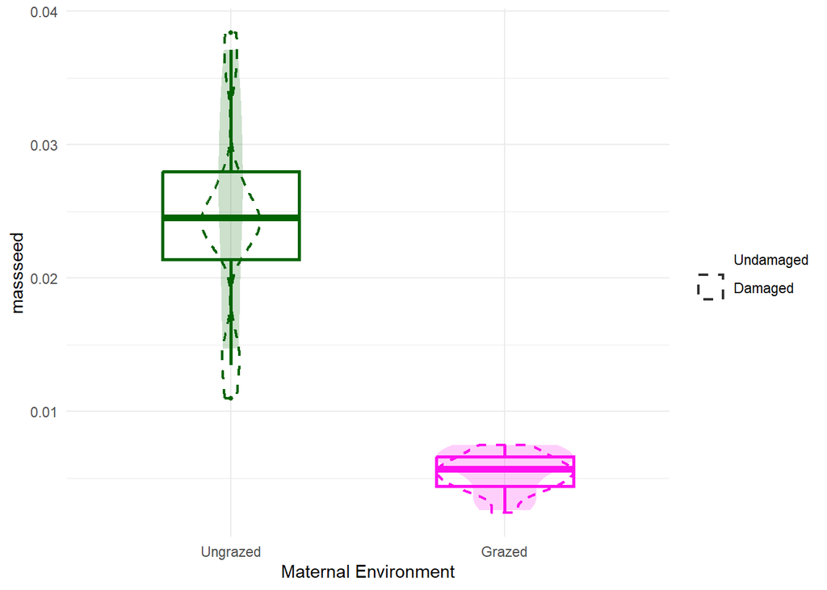

### A.barbata - SLA

**SLA ~ trat + clip + trat:clip**  
n = **44**

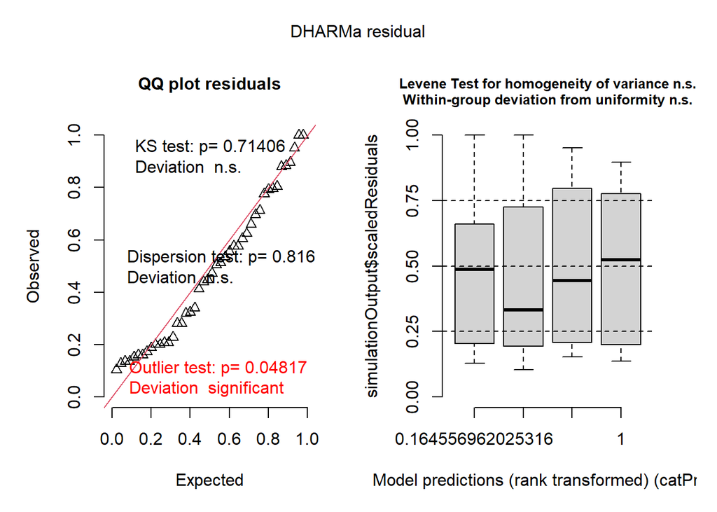

R² = **0.6044889**

##### AVSLA Post-hoc Comparisons with Tukeys HSD

| contrast | trat | estimate | SE | df | t.ratio | p.value |
| --- | --- | --- | --- | --- | --- | --- |
| no - yes | ex | 29.28394 | 26.51865 | 40 | 1.104277 | 0.2760716 |
| no - yes | gra | -95.21340 | 29.04973 | 40 | -3.277601 | 0.0021702 |

| contrast | clip | estimate | SE | df | t.ratio | p.value |
| --- | --- | --- | --- | --- | --- | --- |
| ex - gra | no | -85.91655 | 27.813 | 40 | -3.089079 | 0.0036432 |
| ex - gra | yes | -210.41390 | 27.813 | 40 | -7.565308 | 0.0000000 |

ANOVA Results for AVSLA Model

| Response | Predictor | Sum Sq | Df | F value | Pr(>F) |
| --- | --- | --- | --- | --- | --- |
| AV SLA | trat *** | 239486.55 | 1 | 56.758 | 0.000 |
| AV SLA | clip | 8201.65 | 1 | 1.944 | 0.171 |
| AV SLA | trat:clip ** | 42271.61 | 1 | 10.018 | 0.003 |
| AV SLA | Residuals | 168777.34 | 40 | NA | NA |

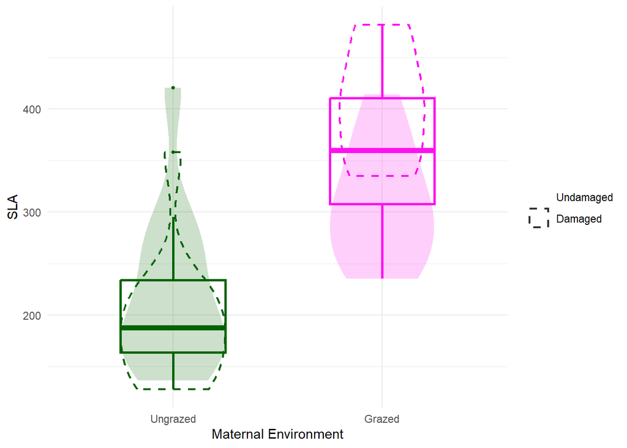

### A.barbata - LDMC

**LDMC ~ trat + clip + trat:clip**  
n = **41**

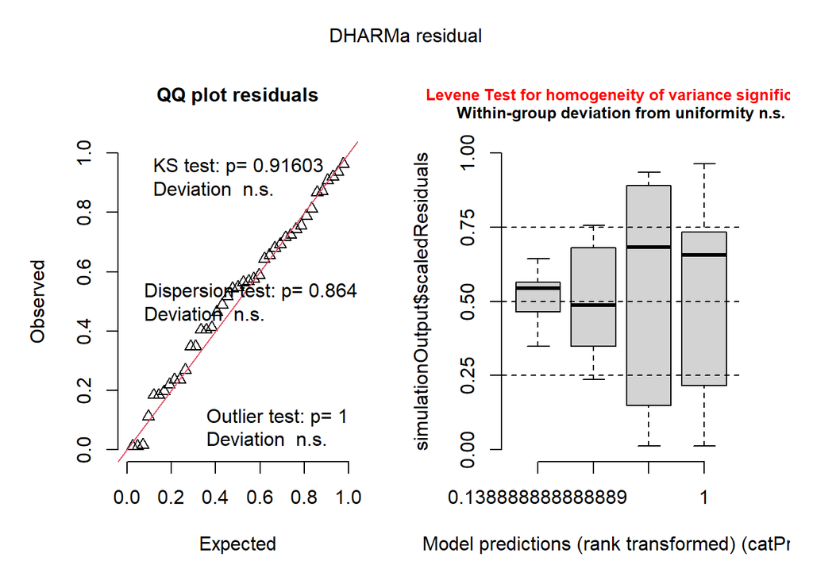

R² = **0.5244003**

##### AVLDMC Post-hoc Comparisons with Tukeys HSD

| contrast | trat | estimate | SE | df | t.ratio | p.value |
| --- | --- | --- | --- | --- | --- | --- |
| no - yes | ex | -0.0247294 | 0.0156384 | 37 | -1.581324 | 0.1223157 |
| no - yes | gra | 0.0209030 | 0.0176608 | 37 | 1.183585 | 0.2441261 |

| contrast | clip | estimate | SE | df | t.ratio | p.value |
| --- | --- | --- | --- | --- | --- | --- |
| ex - gra | no | 0.0552146 | 0.0165201 | 37 | 3.342263 | 0.0019104 |
| ex - gra | yes | 0.1008470 | 0.0168389 | 37 | 5.988941 | 0.0000006 |

ANOVA Results for AVLDMC Model

| Response | Predictor | Sum Sq | Df | F value | Pr(>F) |
| --- | --- | --- | --- | --- | --- |
| AV LDMC | trat *** | 0.061 | 1 | 43.296 | 0.000 |
| AV LDMC | clip | 0.000 | 1 | 0.159 | 0.692 |
| AV LDMC | trat:clip · | 0.005 | 1 | 3.742 | 0.061 |
| AV LDMC | Residuals | 0.052 | 37 | NA | NA |

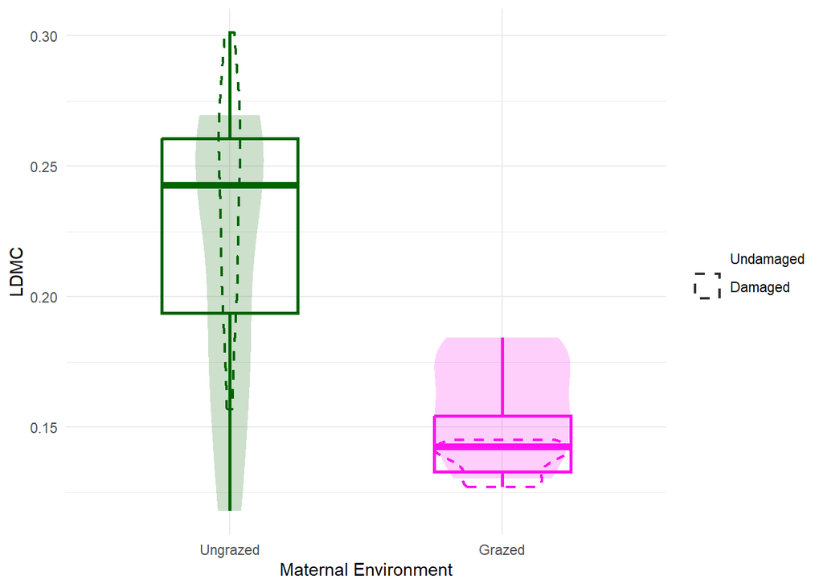

### A.barbata - ÁREA FOLIAR

**area.m ~ trat + clip + trat:clip**  
n = **45**

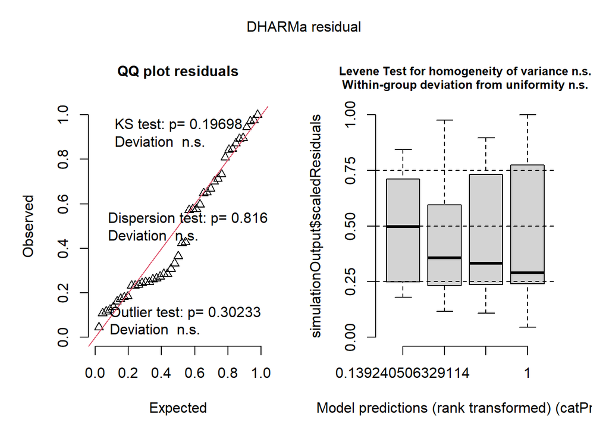

R² = **0.3649783**

##### AVarea.m Post-hoc Comparisons with Tukeys HSD

| contrast | trat | estimate | SE | df | t.ratio | p.value |
| --- | --- | --- | --- | --- | --- | --- |
| no - yes | ex | -0.90025 | 1.580885 | 41 | -0.5694594 | 0.5721514 |
| no - yes | gra | 2.49390 | 1.766069 | 41 | 1.4121192 | 0.1654602 |

| contrast | clip | estimate | SE | df | t.ratio | p.value |
| --- | --- | --- | --- | --- | --- | --- |
| ex - gra | no | 4.35840 | 1.661058 | 41 | 2.623869 | 0.0121555 |
| ex - gra | yes | 7.75255 | 1.690882 | 41 | 4.584914 | 0.0000422 |

ANOVA Results for AVarea.m Model

| Response | Predictor | Sum Sq | Df | F value | Pr(>F) |
| --- | --- | --- | --- | --- | --- |
| AV area.m | trat *** | 403.218 | 1 | 25.856 | 0.000 |
| AV area.m | clip | 4.177 | 1 | 0.268 | 0.608 |
| AV area.m | trat:clip | 31.978 | 1 | 2.051 | 0.160 |
| AV area.m | Residuals | 639.395 | 41 | NA | NA |

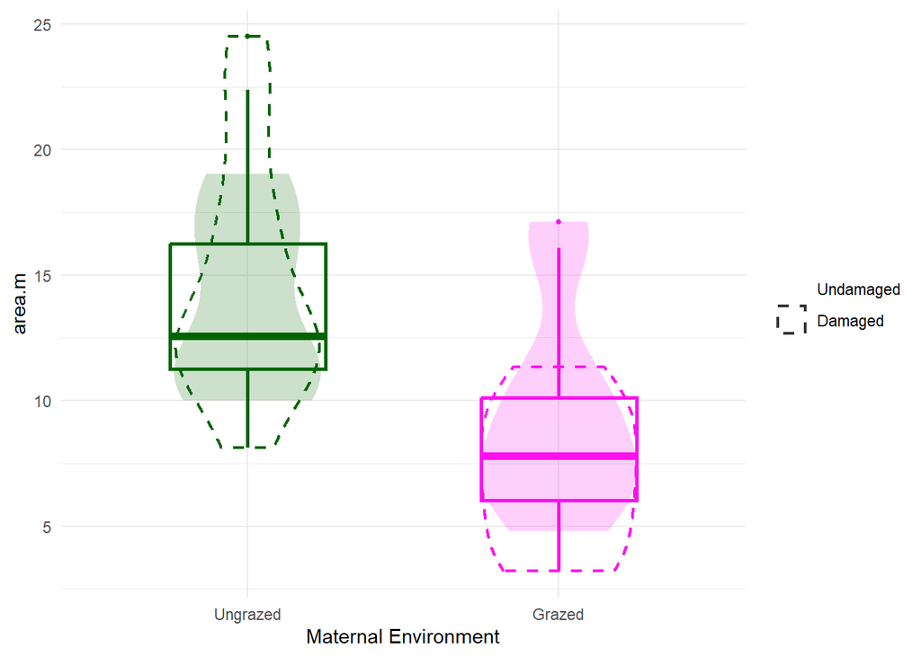

### A.barbata - TASA FOTOSINTÉTICA

**Photosyn ~ trat + clip + trat:clip**  
n = **30**

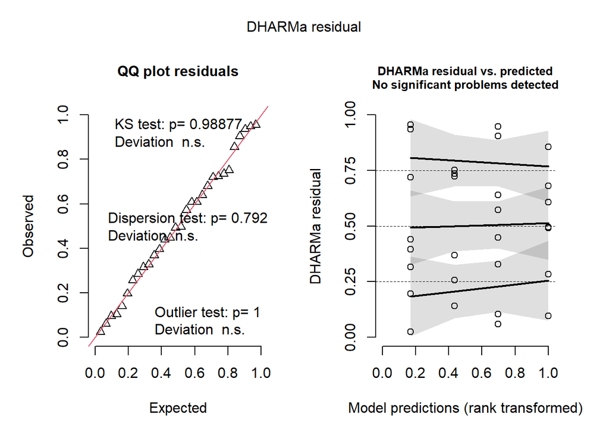

R² = **-0.0149266**

##### AVPhotosyn Post-hoc Comparisons with Tukeys HSD

| contrast | trat | estimate | SE | df | t.ratio | p.value |
| --- | --- | --- | --- | --- | --- | --- |
| no - yes | ex | -0.825 | 2.314778 | 26 | -0.3564057 | 0.7244128 |
| no - yes | gra | 2.800 | 2.500246 | 26 | 1.1198898 | 0.2729997 |

| contrast | clip | estimate | SE | df | t.ratio | p.value |
| --- | --- | --- | --- | --- | --- | --- |
| ex - gra | no | -3.4625 | 2.314778 | 26 | -1.4958238 | 0.1467403 |
| ex - gra | yes | 0.1625 | 2.500246 | 26 | 0.0649936 | 0.9486762 |

ANOVA Results for AVPhotosyn Model

| Response | Predictor | Sum Sq | Df | F value | Pr(>F) |
| --- | --- | --- | --- | --- | --- |
| AV Photosyn | trat | 23.787 | 1 | 1.110 | 0.302 |
| AV Photosyn | clip | 5.343 | 1 | 0.249 | 0.622 |
| AV Photosyn | trat:clip | 24.260 | 1 | 1.132 | 0.297 |
| AV Photosyn | Residuals | 557.253 | 26 | NA | NA |

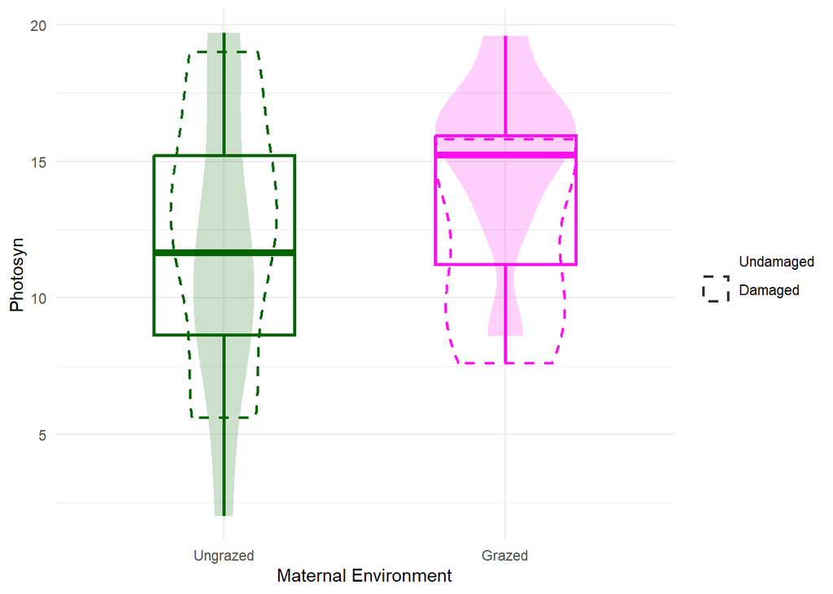

### A.barbata - CONDUCTANCIA ESTOMÁTICA

**Conductance ~ trat + clip + trat:clip**  
n = **30**

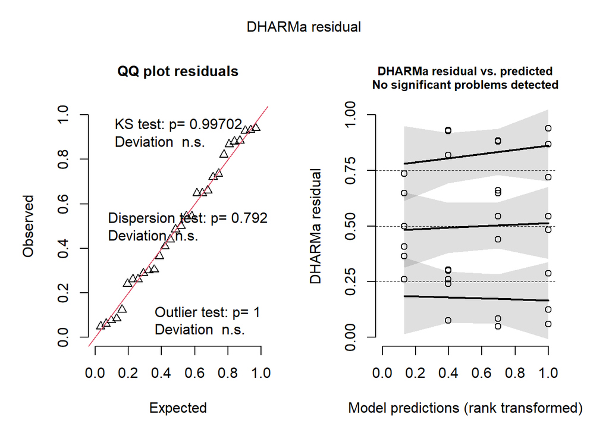

R² = **0.086454**

##### AVConductance Post-hoc Comparisons with Tukeys HSD

| contrast | trat | estimate | SE | df | t.ratio | p.value |
| --- | --- | --- | --- | --- | --- | --- |
| no - yes | ex | -0.067625 | 0.0395404 | 26 | -1.710275 | 0.0991241 |
| no - yes | gra | 0.071125 | 0.0427085 | 26 | 1.665358 | 0.1078472 |

| contrast | clip | estimate | SE | df | t.ratio | p.value |
| --- | --- | --- | --- | --- | --- | --- |
| ex - gra | no | -0.07050 | 0.0395404 | 26 | -1.782986 | 0.0862693 |
| ex - gra | yes | 0.06825 | 0.0427085 | 26 | 1.598041 | 0.1221175 |

ANOVA Results for AVConductance Model

| Response | Predictor | Sum Sq | Df | F value | Pr(>F) |
| --- | --- | --- | --- | --- | --- |
| AV Conductance | trat | 0.000 | 1 | 0.050 | 0.826 |
| AV Conductance | clip | 0.000 | 1 | 0.015 | 0.903 |
| AV Conductance | trat:clip * | 0.036 | 1 | 5.683 | 0.025 |
| AV Conductance | Residuals | 0.163 | 26 | NA | NA |

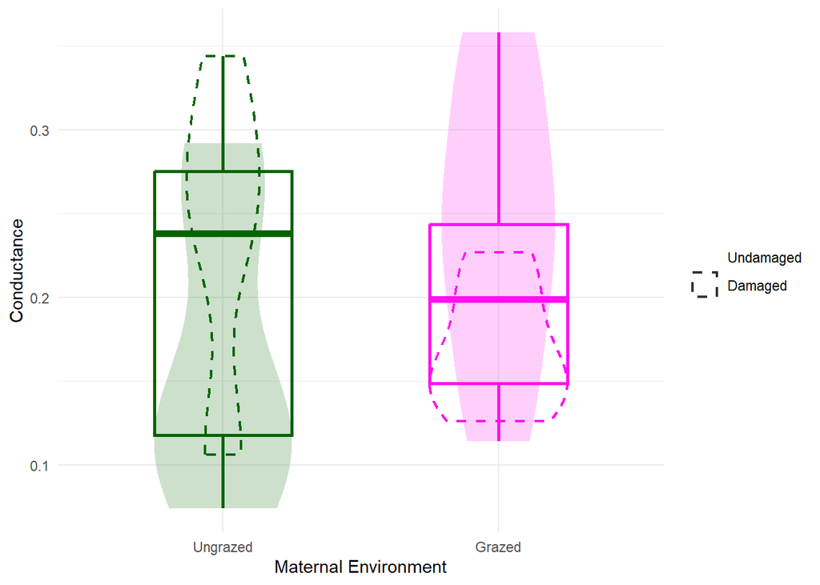

### A.barbata - EFICIENCIA DEL FOTOSISTEMA II

**PhiPS2 ~ trat + clip + trat:clip**  
n = **30**

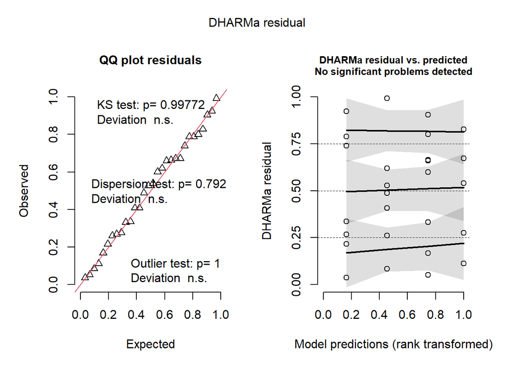

R² = **0.1984548**

##### AVPhiPS2 Post-hoc Comparisons with Tukeys HSD

| contrast | trat | estimate | SE | df | t.ratio | p.value |
| --- | --- | --- | --- | --- | --- | --- |
| no - yes | ex | -0.0120000 | 0.0198413 | 26 | -0.6047979 | 0.5505556 |
| no - yes | gra | -0.0133333 | 0.0214311 | 26 | -0.6221490 | 0.5392621 |

| contrast | clip | estimate | SE | df | t.ratio | p.value |
| --- | --- | --- | --- | --- | --- | --- |
| ex - gra | no | -0.0448750 | 0.0198413 | 26 | -2.261692 | 0.0323083 |
| ex - gra | yes | -0.0462083 | 0.0214311 | 26 | -2.156135 | 0.0405027 |

ANOVA Results for AVPhiPS2 Model

| Response | Predictor | Sum Sq | Df | F value | Pr(>F) |
| --- | --- | --- | --- | --- | --- |
| AV PhiPS2 | trat ** | 0.015 | 1 | 9.762 | 0.004 |
| AV PhiPS2 | clip | 0.001 | 1 | 0.751 | 0.394 |
| AV PhiPS2 | trat:clip | 0.000 | 1 | 0.002 | 0.964 |
| AV PhiPS2 | Residuals | 0.041 | 26 | NA | NA |

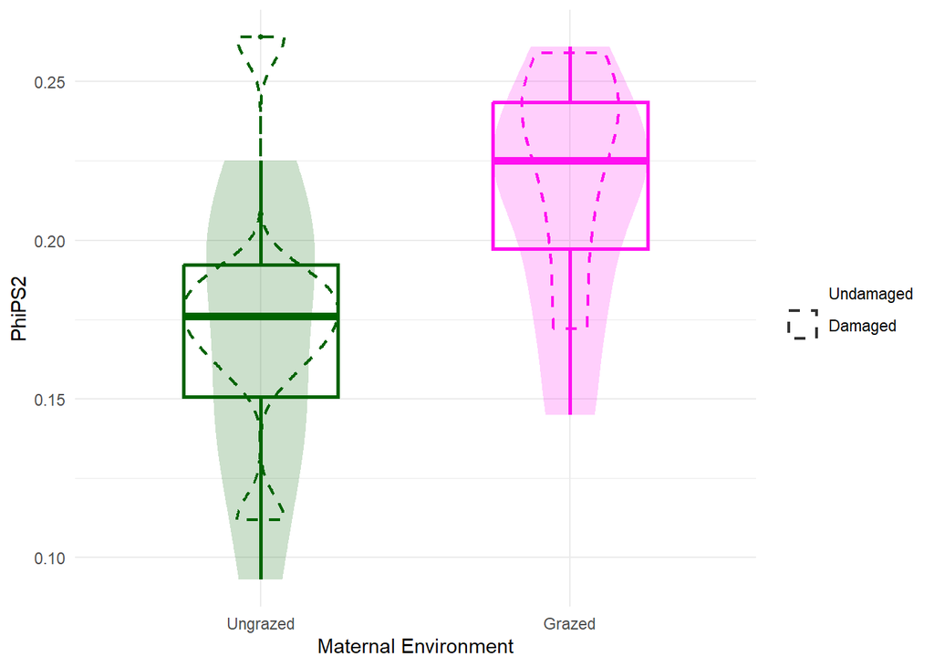

### A.barbata - FENOLOGÍA DE FLORACIÓN

**dias_flor ~ trat + clip + trat:clip**  
n = **50**

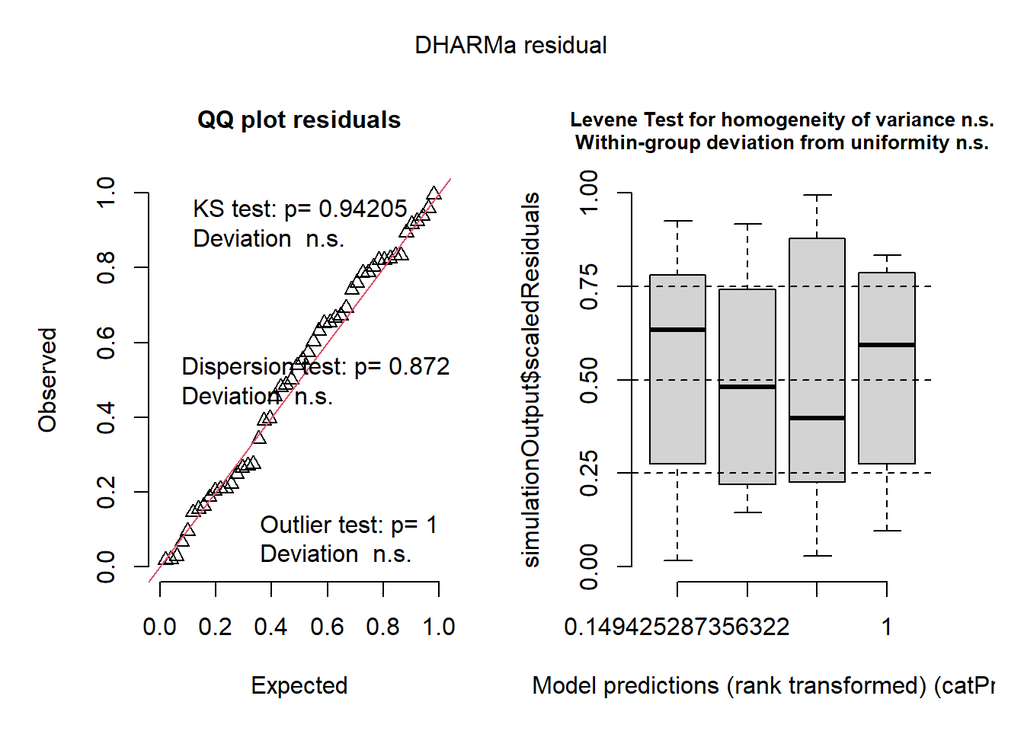

##### AVdias_flor Post-hoc Comparisons with Tukeys HSD

| contrast | trat | estimate | SE | df | z.ratio | p.value |
| --- | --- | --- | --- | --- | --- | --- |
| no - yes | ex | -0.0609793 | 0.0492279 | Inf | -1.2387135 | 0.2154516 |
| no - yes | gra | 0.0186691 | 0.0538118 | Inf | 0.3469338 | 0.7286411 |

| contrast | clip | estimate | SE | df | z.ratio | p.value |
| --- | --- | --- | --- | --- | --- | --- |
| ex - gra | no | -0.0059589 | 0.0527234 | Inf | -0.1130224 | 0.9100128 |
| ex - gra | yes | 0.0736895 | 0.0503918 | Inf | 1.4623303 | 0.1436507 |

ANOVA Results for AVdias_flor Model

| Response | Predictor | Chisq | Df | Pr(>Chisq) |
| --- | --- | --- | --- | --- |
| AV dias_flor | trat | 0.959 | 1 | 0.328 |
| AV dias_flor | clip | 0.462 | 1 | 0.497 |
| AV dias_flor | trat:clip | 1.193 | 1 | 0.275 |

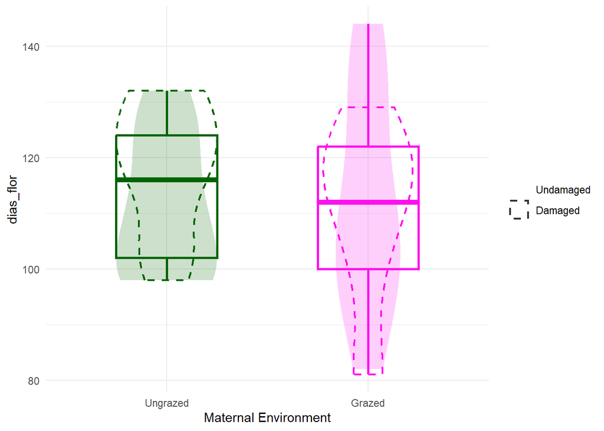

### A.barbata - FENOLOGÍA DE FRUCTIFICACÓN

**dias_fruto ~ trat + clip + trat:clip**  
n = **35**

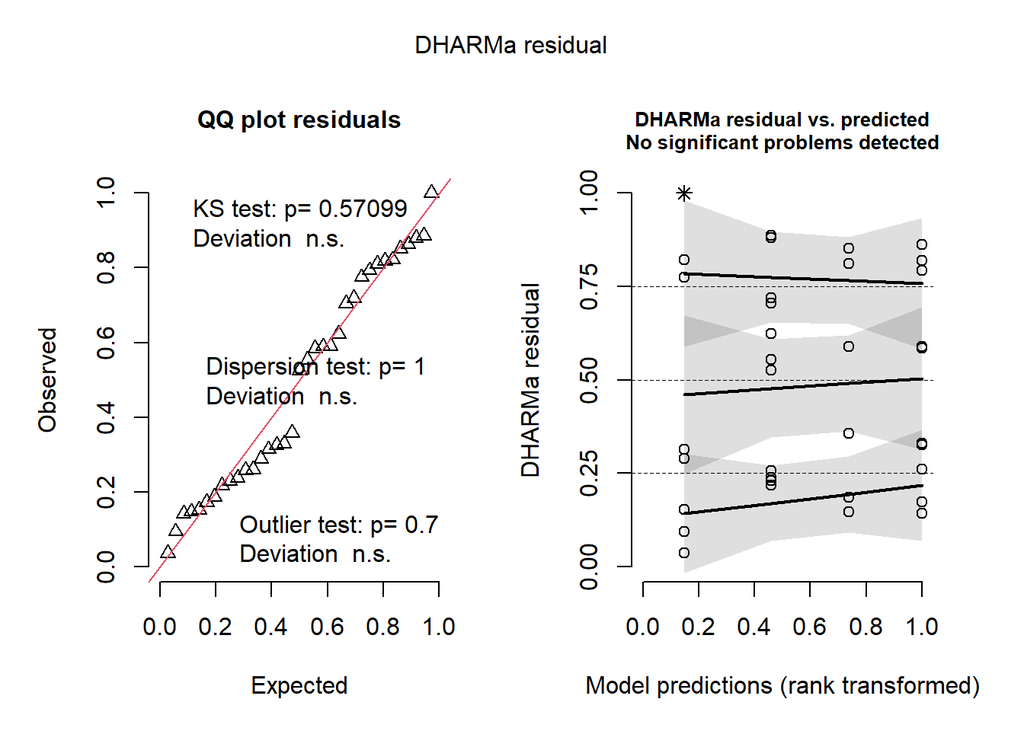

##### AVdias_fruto Post-hoc Comparisons with Tukeys HSD

| contrast | trat | estimate | SE | df | z.ratio | p.value |
| --- | --- | --- | --- | --- | --- | --- |
| no - yes | ex | -0.0173222 | 0.0453227 | Inf | -0.3821978 | 0.7023147 |
| no - yes | gra | -0.0380366 | 0.0426091 | Inf | -0.8926877 | 0.3720245 |

| contrast | clip | estimate | SE | df | z.ratio | p.value |
| --- | --- | --- | --- | --- | --- | --- |
| ex - gra | no | 0.0172856 | 0.0419378 | Inf | 0.4121731 | 0.6802126 |
| ex - gra | yes | -0.0034287 | 0.0459445 | Inf | -0.0746276 | 0.9405110 |

ANOVA Results for AVdias_fruto Model

| Response | Predictor | Chisq | Df | Pr(>Chisq) |
| --- | --- | --- | --- | --- |
| AV dias_fruto | trat | 0.065 | 1 | 0.799 |
| AV dias_fruto | clip | 0.832 | 1 | 0.362 |
| AV dias_fruto | trat:clip | 0.111 | 1 | 0.739 |

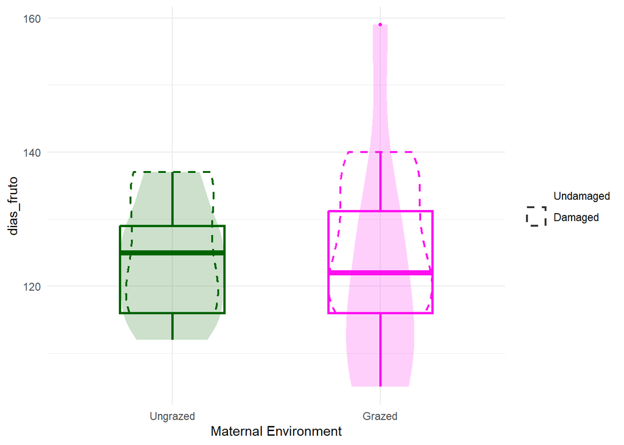

### A.barbata - PERIODO DE FLORACIÓN

**periodo_flor ~ trat + clip + trat:clip**  
n = **14**

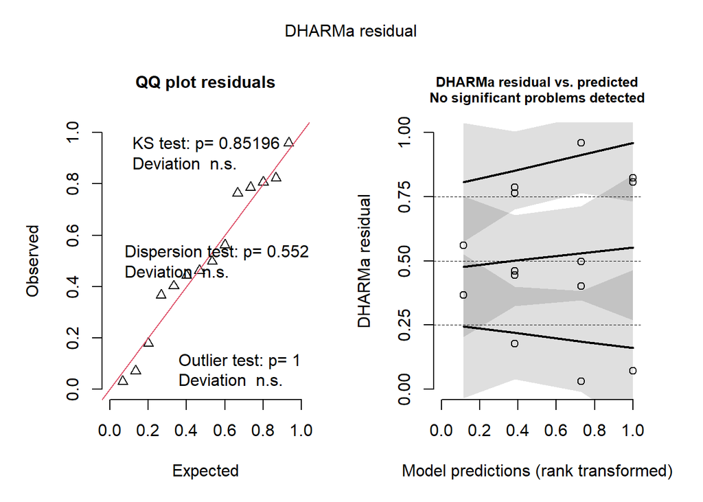

##### AVperiodo_flor Post-hoc Comparisons with Tukeys HSD

| contrast | trat | estimate | SE | df | z.ratio | p.value |
| --- | --- | --- | --- | --- | --- | --- |
| no - yes | ex | -0.1015883 | 0.1609497 | Inf | -0.6311807 | 0.5279224 |
| no - yes | gra | -1.1478836 | 0.2468436 | Inf | -4.6502455 | 0.0000033 |

| contrast | clip | estimate | SE | df | z.ratio | p.value |
| --- | --- | --- | --- | --- | --- | --- |
| ex - gra | no | 0.6991896 | 0.2380560 | Inf | 2.937080 | 0.0033132 |
| ex - gra | yes | -0.3471056 | 0.1736834 | Inf | -1.998496 | 0.0456629 |

ANOVA Results for AVperiodo_flor Model

| Response | Predictor | Chisq | Df | Pr(>Chisq) |
| --- | --- | --- | --- | --- |
| AV periodo_flor | trat | 0.014 | 1 | 0.907 |
| AV periodo_flor | clip ** | 9.416 | 1 | 0.002 |
| AV periodo_flor | trat:clip *** | 12.607 | 1 | 0.000 |

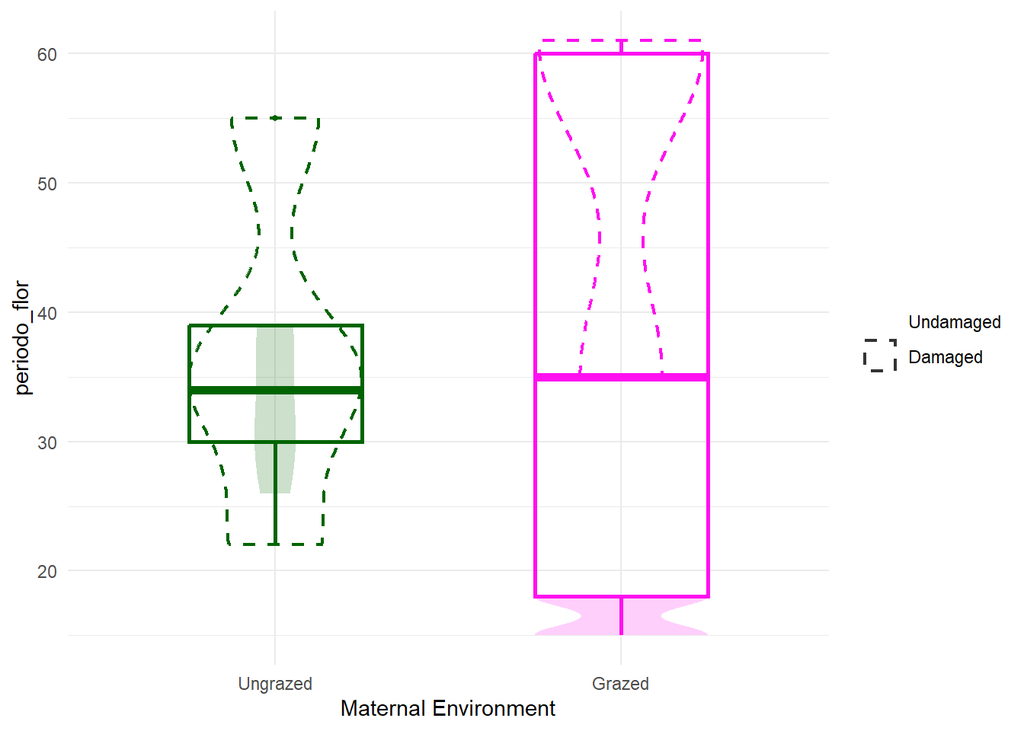

### A.barbata - PERIODO DE FRUCTIFICACIÓN

**periodo_fruto ~ trat + clip + trat:clip**

n = **13**

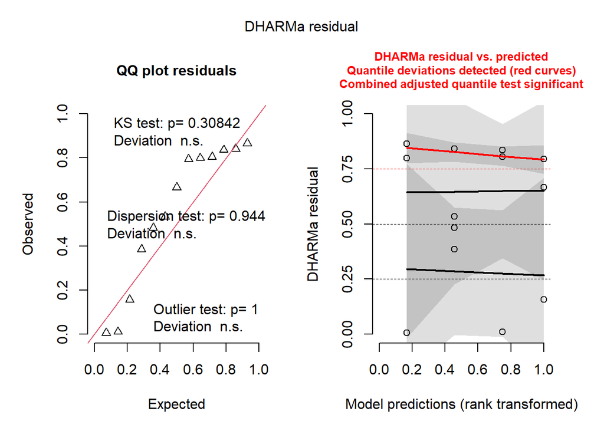

##### AVperiodo_fruto Post-hoc Comparisons with Tukeys HSD

| contrast | trat | estimate | SE | df | z.ratio | p.value |
| --- | --- | --- | --- | --- | --- | --- |
| no - yes | ex | -0.3175351 | 0.3435723 | Inf | -0.9242161 | 0.3553738 |
| no - yes | gra | -2.0368819 | 0.3768579 | Inf | -5.4049065 | 0.0000001 |

| contrast | clip | estimate | SE | df | z.ratio | p.value |
| --- | --- | --- | --- | --- | --- | --- |
| ex - gra | no | 0.5007754 | 0.3940772 | Inf | 1.270754 | 0.2038160 |
| ex - gra | yes | -1.2185715 | 0.3236773 | Inf | -3.764773 | 0.0001667 |

ANOVA Results for AVperiodo_fruto Model

| Response | Predictor | Chisq | Df | Pr(>Chisq) |
| --- | --- | --- | --- | --- |
| AV periodo_fruto | trat * | 4.421 | 1 | 0.035 |
| AV periodo_fruto | clip *** | 18.700 | 1 | 0.000 |
| AV periodo_fruto | trat:clip *** | 11.367 | 1 | 0.001 |

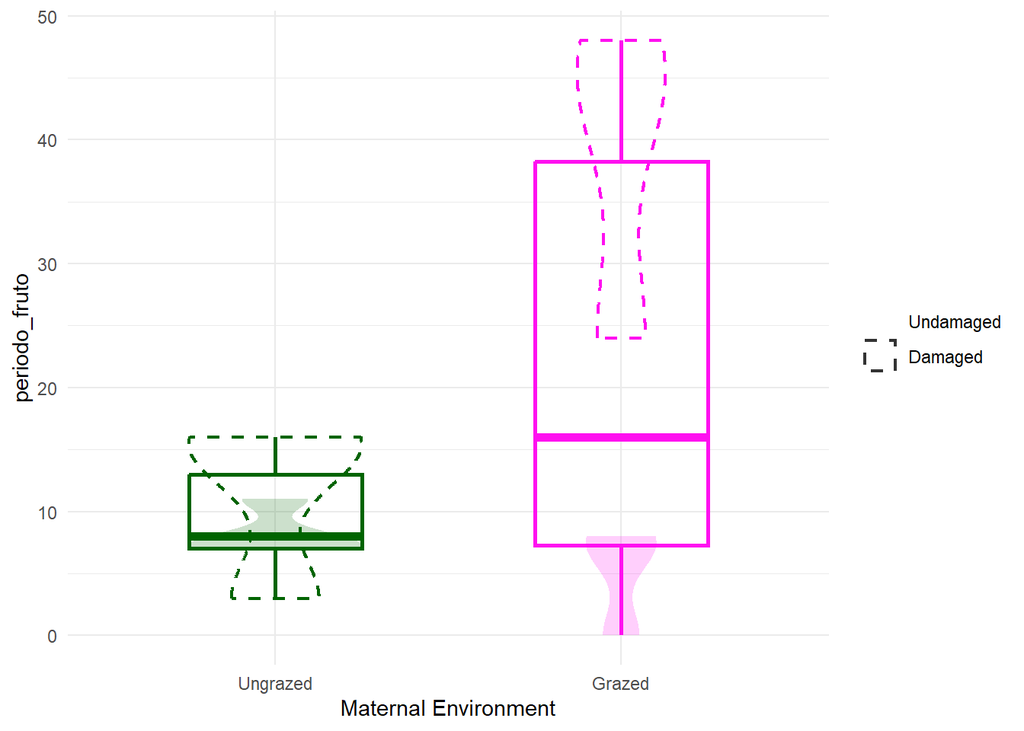

### A.barbata - dias_fin DE FLORACIÓN

**dias_fin_flor ~ trat + clip + trat:clip**  
n = **14**

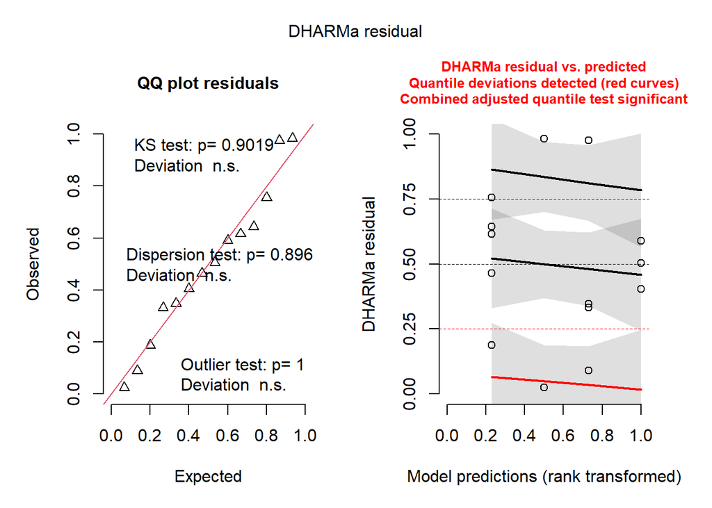

##### AVdias_fin_flor Post-hoc Comparisons with Tukeys HSD

| contrast | trat | estimate | SE | df | z.ratio | p.value |
| --- | --- | --- | --- | --- | --- | --- |
| no - yes | ex | -0.0908908 | 0.0565342 | Inf | -1.607714 | 0.1078978 |
| no - yes | gra | -0.1660279 | 0.0754304 | Inf | -2.201074 | 0.0277308 |

| contrast | clip | estimate | SE | df | z.ratio | p.value |
| --- | --- | --- | --- | --- | --- | --- |
| ex - gra | no | -0.0257842 | 0.0716163 | Inf | -0.3600324 | 0.7188229 |
| ex - gra | yes | -0.1009213 | 0.0612941 | Inf | -1.6465102 | 0.0996588 |

ANOVA Results for AVdias_fin_flor Model

| Response | Predictor | Chisq | Df | Pr(>Chisq) |
| --- | --- | --- | --- | --- |
| AV dias_fin_flor | trat | 2.205 | 1 | 0.138 |
| AV dias_fin_flor | clip ** | 6.794 | 1 | 0.009 |
| AV dias_fin_flor | trat:clip | 0.635 | 1 | 0.425 |

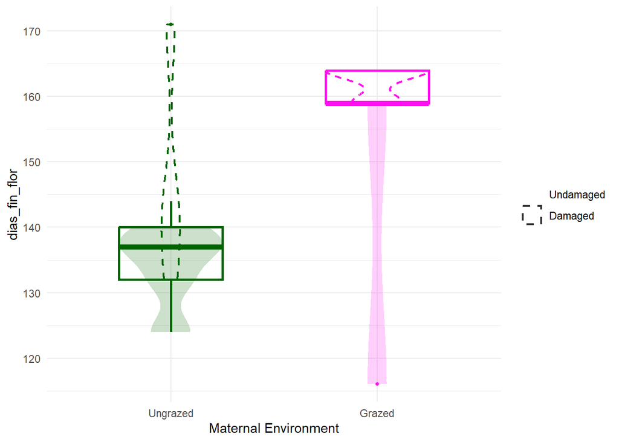

### A.barbata - dias_fin DE FRUCTIFICACIÓN

**dias_fin_fruto ~ trat + clip + trat:clip**

n = **14**

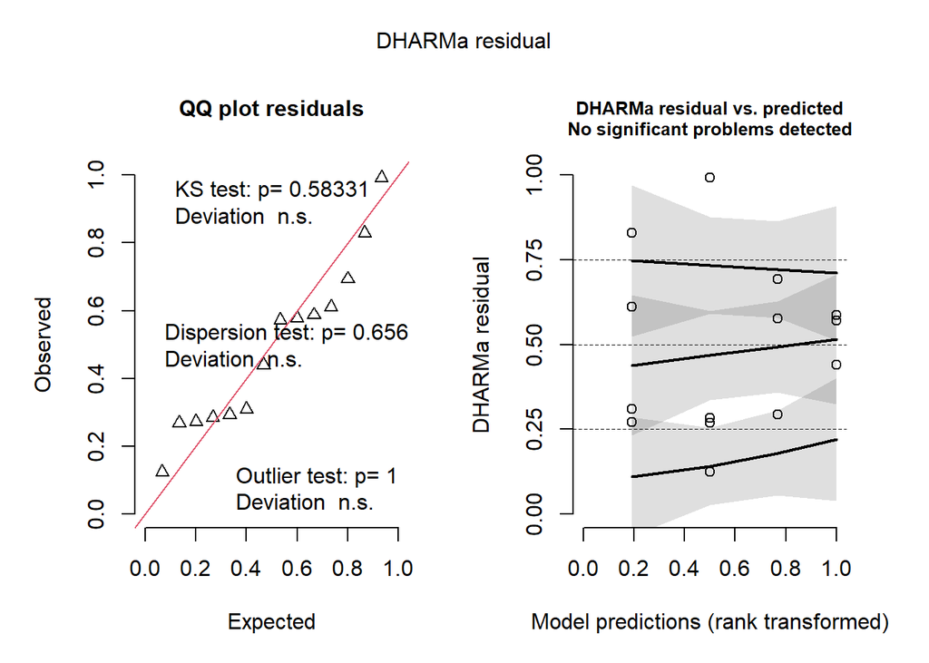

##### AVdias_fin_fruto Post-hoc Comparisons with Tukeys HSD

| contrast | trat | estimate | SE | df | z.ratio | p.value |
| --- | --- | --- | --- | --- | --- | --- |
| no - yes | ex | -0.0664633 | 0.0658075 | Inf | -1.009965 | 0.3125121 |
| no - yes | gra | -0.2201963 | 0.0630300 | Inf | -3.493517 | 0.0004767 |

| contrast | clip | estimate | SE | df | z.ratio | p.value |
| --- | --- | --- | --- | --- | --- | --- |
| ex - gra | no | -0.0038460 | 0.0620175 | Inf | -0.0620141 | 0.9505516 |
| ex - gra | yes | -0.1575789 | 0.0667625 | Inf | -2.3602897 | 0.0182607 |

ANOVA Results for AVdias_fin_fruto Model

| Response | Predictor | Chisq | Df | Pr(>Chisq) |
| --- | --- | --- | --- | --- |
| AV dias_fin_fruto | trat · | 2.729 | 1 | 0.099 |
| AV dias_fin_fruto | clip ** | 10.378 | 1 | 0.001 |
| AV dias_fin_fruto | trat:clip · | 2.846 | 1 | 0.092 |

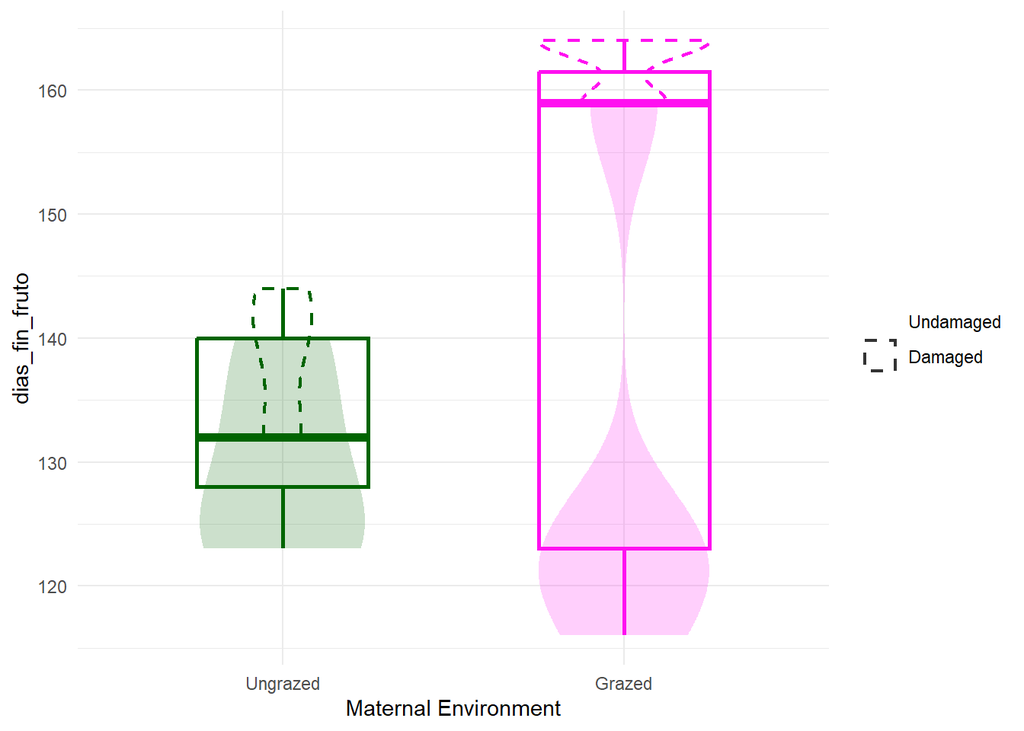

### A.barbata - ESPERANZA DE VIDA

**dias_muerte ~ trat + clip + trat:clip**  
n = **10**

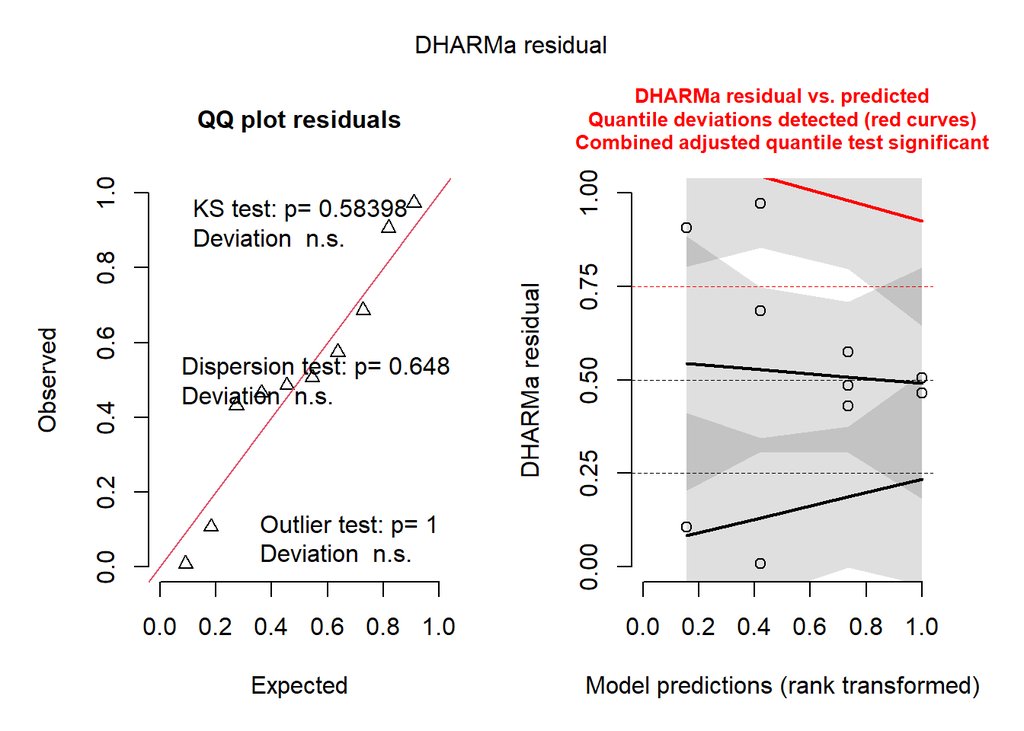

##### AVdias_muerte Post-hoc Comparisons with Tukeys HSD

| contrast | trat | estimate | SE | df | z.ratio | p.value |
| --- | --- | --- | --- | --- | --- | --- |
| no - yes | ex | 0.1150014 | 0.0716378 | Inf | 1.605318 | 0.1084239 |
| no - yes | gra | -0.1236139 | 0.0740984 | Inf | -1.668239 | 0.0952682 |

| contrast | clip | estimate | SE | df | z.ratio | p.value |
| --- | --- | --- | --- | --- | --- | --- |
| ex - gra | no | 0.1662947 | 0.0799421 | Inf | 2.080190 | 0.0375081 |
| ex - gra | yes | -0.0723206 | 0.0650524 | Inf | -1.111729 | 0.2662547 |

ANOVA Results for AVdias_muerte Model

| Response | Predictor | Chisq | Df | Pr(>Chisq) |
| --- | --- | --- | --- | --- |
| AV dias_muerte | trat | 0.203 | 1 | 0.652 |
| AV dias_muerte | clip | 0.000 | 1 | 0.996 |
| AV dias_muerte | trat:clip * | 5.360 | 1 | 0.021 |

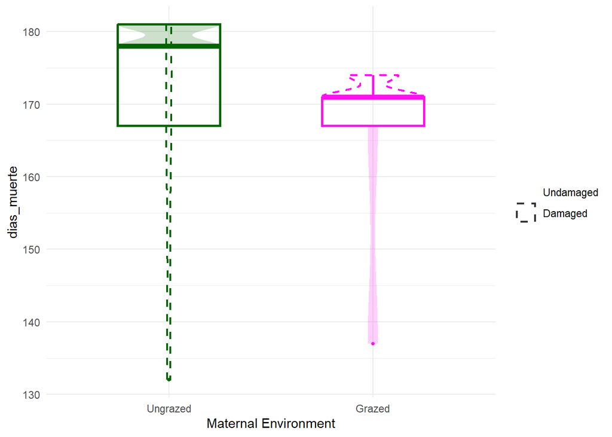

### A.barbata - FENOLES

**fenoles ~ trat + clip + trat:clip**  
n = **49**

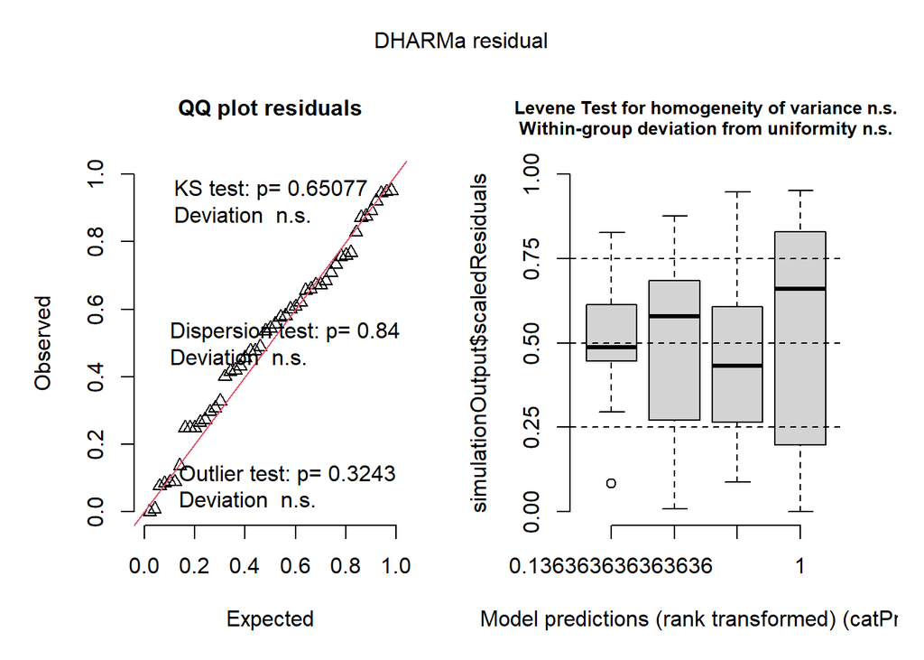

R² = **0.237726**

##### AVfenoles Post-hoc Comparisons with Tukeys HSD

| contrast | trat | estimate | SE | df | t.ratio | p.value |
| --- | --- | --- | --- | --- | --- | --- |
| no - yes | ex | 0.3251818 | 3.380990 | 45 | 0.0961795 | 0.9238051 |
| no - yes | gra | 5.0093007 | 3.437731 | 45 | 1.4571532 | 0.1520174 |

| contrast | clip | estimate | SE | df | t.ratio | p.value |
| --- | --- | --- | --- | --- | --- | --- |
| ex - gra | no | -12.113454 | 3.380990 | 45 | -3.582812 | 0.0008309 |
| ex - gra | yes | -7.429336 | 3.437731 | 45 | -2.161116 | 0.0360459 |

ANOVA Results for AVfenoles Model

| Response | Predictor | Sum Sq | Df | F value | Pr(>F) |
| --- | --- | --- | --- | --- | --- |
| AV fenoles | trat *** | 1166.309 | 1 | 16.563 | 0.000 |
| AV fenoles | clip | 83.711 | 1 | 1.189 | 0.281 |
| AV fenoles | trat:clip | 66.454 | 1 | 0.944 | 0.337 |
| AV fenoles | Residuals | 3168.700 | 45 | NA | NA |

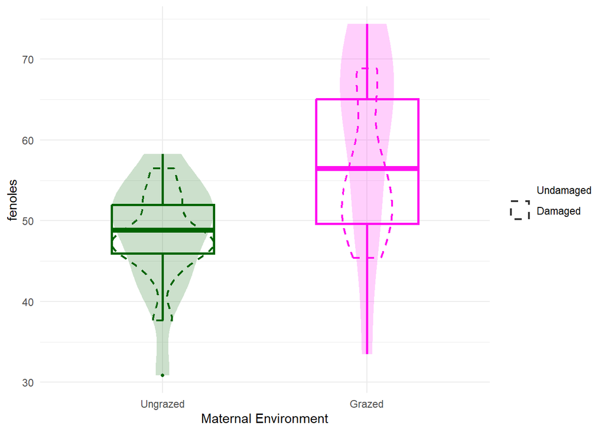

### A.barbata - BIOMASA

**biomass ~ trat + clip + trat:clip**  
n = **53**

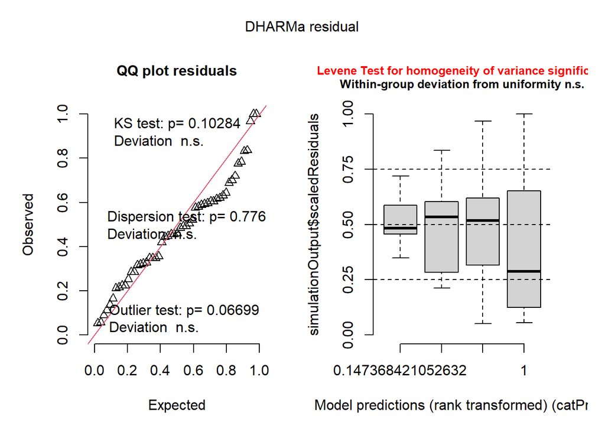

R² = **0.3635947**

##### AVbiomass Post-hoc Comparisons with Tukeys HSD

| contrast | trat | estimate | SE | df | t.ratio | p.value |
| --- | --- | --- | --- | --- | --- | --- |
| no - yes | ex | 0.4169857 | 0.3540197 | 49 | 1.177860 | 0.2445415 |
| no - yes | gra | 1.9966218 | 0.3749594 | 49 | 5.324902 | 0.0000025 |

| contrast | clip | estimate | SE | df | t.ratio | p.value |
| --- | --- | --- | --- | --- | --- | --- |
| ex - gra | no | -1.2736905 | 0.3684754 | 49 | -3.4566496 | 0.0011397 |
| ex - gra | yes | 0.3059456 | 0.3607636 | 49 | 0.8480501 | 0.4005338 |

ANOVA Results for AVbiomass Model

| Response | Predictor | Sum Sq | Df | F value | Pr(>F) |
| --- | --- | --- | --- | --- | --- |
| AV biomass | trat · | 2.881 | 1 | 3.284 | 0.076 |
| AV biomass | clip *** | 17.861 | 1 | 20.359 | 0.000 |
| AV biomass | trat:clip ** | 8.232 | 1 | 9.383 | 0.004 |
| AV biomass | Residuals | 42.988 | 49 | NA | NA |

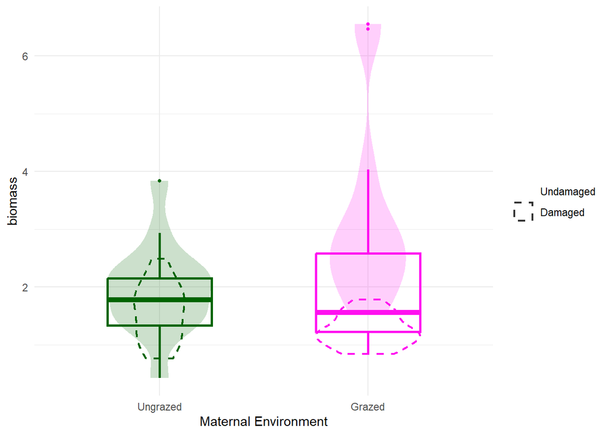

### A.barbata - Diámetro de la raíz

**AvgDiam.mm. ~ trat + clip + trat:clip**  
n = **43**

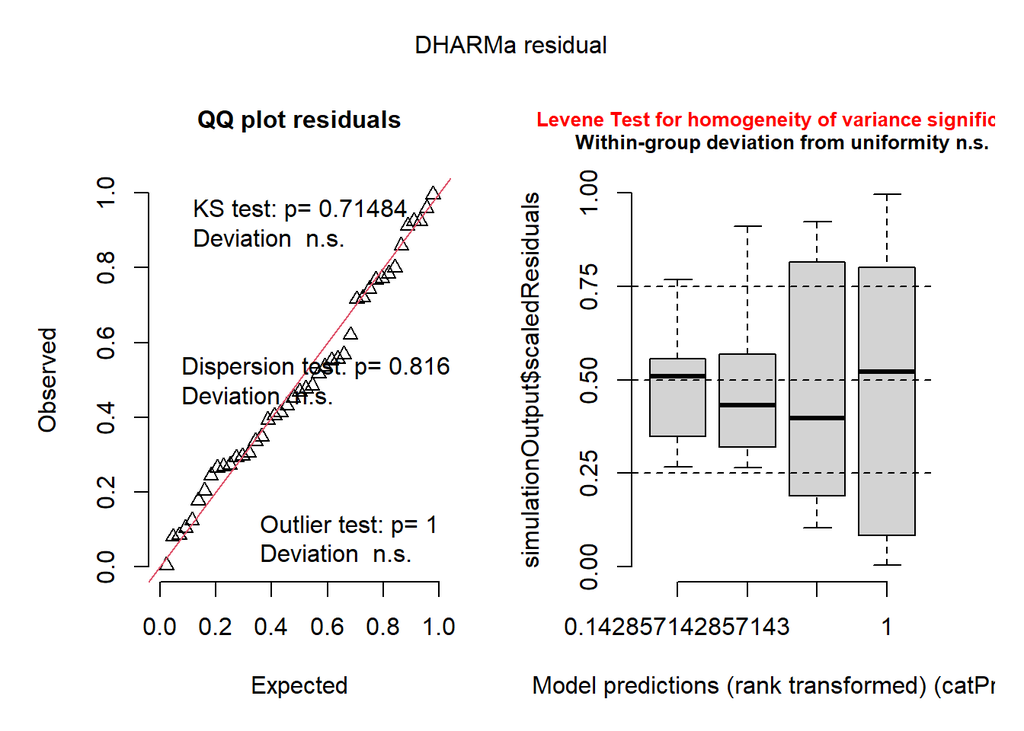

R² = **0.2704499**

##### AVAvgDiam.mm. Post-hoc Comparisons with Tukeys HSD

| contrast | trat | estimate | SE | df | t.ratio | p.value |
| --- | --- | --- | --- | --- | --- | --- |
| no - yes | ex | 0.0907417 | 0.0371446 | 39 | 2.44293 | 0.0191998 |
| no - yes | gra | 0.1412700 | 0.0397955 | 39 | 3.54990 | 0.0010238 |

| contrast | clip | estimate | SE | df | t.ratio | p.value |
| --- | --- | --- | --- | --- | --- | --- |
| ex - gra | no | -0.0270983 | 0.0381013 | 39 | -0.7112186 | 0.4811812 |
| ex - gra | yes | 0.0234300 | 0.0388805 | 39 | 0.6026154 | 0.5502528 |

ANOVA Results for AVAvgDiam.mm. Model

| Response | Predictor | Sum Sq | Df | F value | Pr(>F) |
| --- | --- | --- | --- | --- | --- |
| AV AvgDiam.mm. | trat | 0.000 | 1 | 0.007 | 0.932 |
| AV AvgDiam.mm. | clip *** | 0.140 | 1 | 17.708 | 0.000 |
| AV AvgDiam.mm. | trat:clip | 0.007 | 1 | 0.862 | 0.359 |
| AV AvgDiam.mm. | Residuals | 0.309 | 39 | NA | NA |

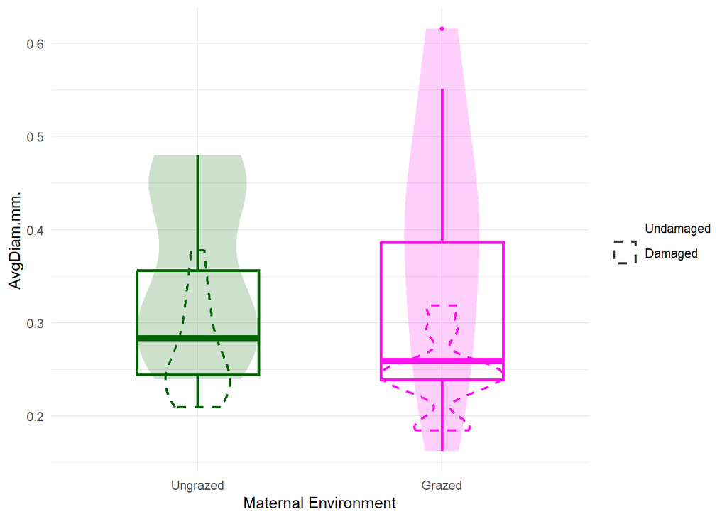

### A.barbata - Root Tissue Density (RTD)

**RTD ~ trat + clip + trat:clip**  
n = **43**

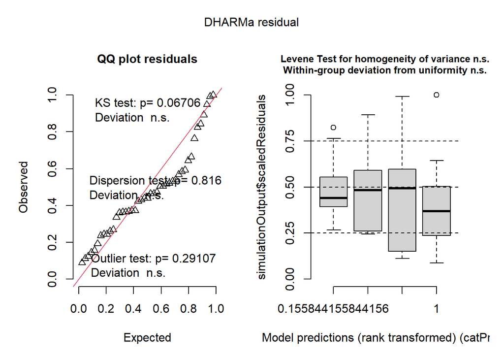

R² = **0.1039599**

##### AVRTD Post-hoc Comparisons with Tukeys HSD

| contrast | trat | estimate | SE | df | t.ratio | p.value |
| --- | --- | --- | --- | --- | --- | --- |
| no - yes | ex | 0.1066919 | 0.0486472 | 39 | 2.193178 | 0.0343231 |
| no - yes | gra | 0.0903058 | 0.0521189 | 39 | 1.732686 | 0.0910537 |

| contrast | clip | estimate | SE | df | t.ratio | p.value |
| --- | --- | --- | --- | --- | --- | --- |
| ex - gra | no | -0.0029029 | 0.0499001 | 39 | -0.0581742 | 0.9539069 |
| ex - gra | yes | -0.0192890 | 0.0509206 | 39 | -0.3788058 | 0.7068866 |

ANOVA Results for AVRTD Model

| Response | Predictor | Sum Sq | Df | F value | Pr(>F) |
| --- | --- | --- | --- | --- | --- |
| AV RTD | trat | 0.001 | 1 | 0.094 | 0.761 |
| AV RTD | clip ** | 0.105 | 1 | 7.759 | 0.008 |
| AV RTD | trat:clip | 0.001 | 1 | 0.053 | 0.819 |
| AV RTD | Residuals | 0.530 | 39 | NA | NA |

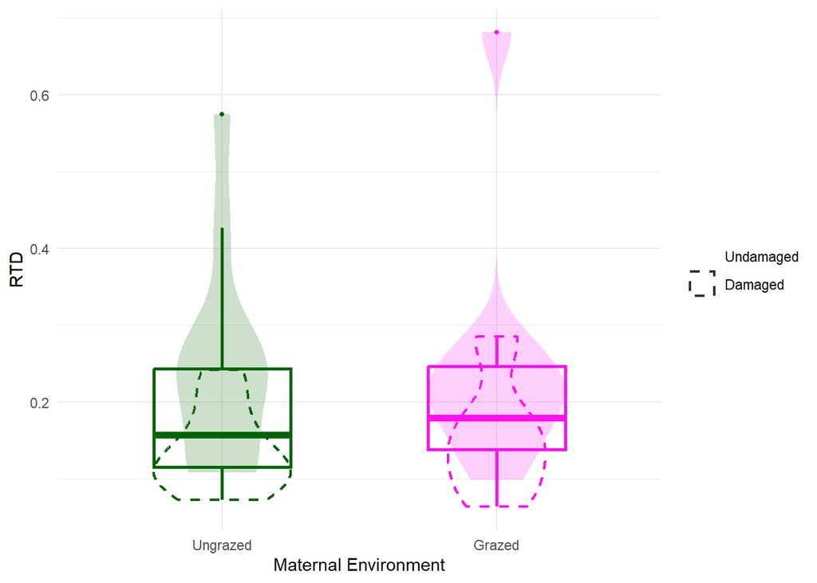

### A.barbata - Specific Root Length (SRL)

**SRL ~ trat + clip + trat:clip**  
n = **43**

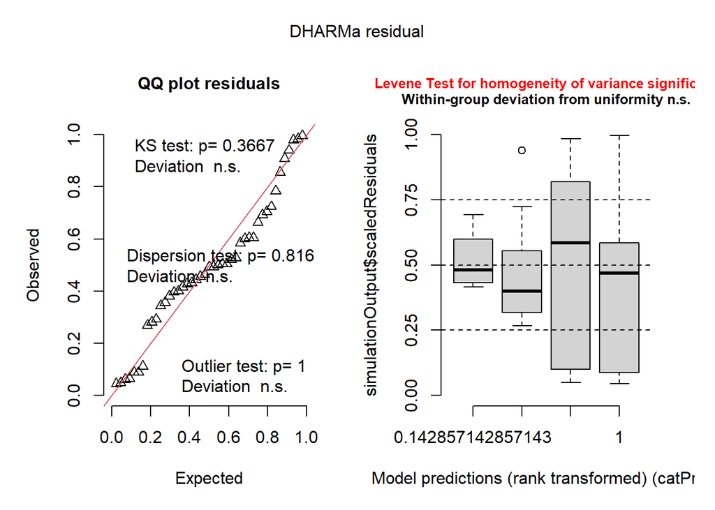

R² = **0.2662918**

##### AVSRL Post-hoc Comparisons with Tukeys HSD

| contrast | trat | estimate | SE | df | t.ratio | p.value |
| --- | --- | --- | --- | --- | --- | --- |
| no - yes | ex | 0.0267373 | 0.0101939 | 39 | 2.622872 | 0.0123761 |
| no - yes | gra | 0.0368166 | 0.0109214 | 39 | 3.371052 | 0.0016996 |

| contrast | clip | estimate | SE | df | t.ratio | p.value |
| --- | --- | --- | --- | --- | --- | --- |
| ex - gra | no | -0.0056475 | 0.0104564 | 39 | -0.5400946 | 0.5922028 |
| ex - gra | yes | 0.0044319 | 0.0106703 | 39 | 0.4153447 | 0.6801659 |

ANOVA Results for AVSRL Model

| Response | Predictor | Sum Sq | Df | F value | Pr(>F) |
| --- | --- | --- | --- | --- | --- |
| AV SRL | trat | 0.000 | 1 | 0.009 | 0.925 |
| AV SRL | clip *** | 0.011 | 1 | 17.788 | 0.000 |
| AV SRL | trat:clip | 0.000 | 1 | 0.455 | 0.504 |
| AV SRL | Residuals | 0.023 | 39 | NA | NA |

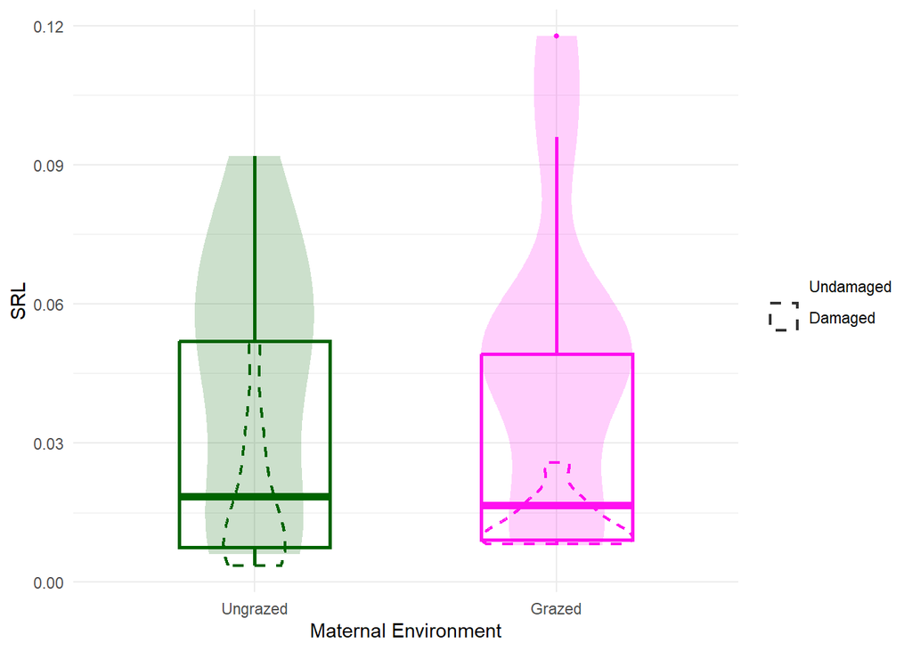